# Crash Course in R

Matthew E. Aiello-Lammens

## Use a script file

Let’s all make a new directory to work in today.

Let’s create a new script file in that directory.

Scripts make it easier to repeat your work. You can also add comments using the pound sign.

Short cut to execute commands and functions:

Mac: [Command] + return

Windows [Control] + return (RStudio) [Control] + r (R gui)

### Setting your working directory

```r
setwd("[your dir name here]")
```

## R as a calculator

```r
5 + 3
```

```
## [1] 8
```

```r
8^3
```

```
## [1] 512
```

```r
6*3-1
```

```
## [1] 17
```

```r
# Order of operations follows PEMDAS
6*(3-1)
```

```
## [1] 12
```

## Variables

We can save things within our session as **variables**

```r
pop_1 <- 1200
pop_2 <- 500

pop_total <- pop_1 + pop_2

pop_1 * 2
```

```
## [1] 2400
```

```r
# Etc.
```

### Challange

I chagne pop_1

```r
pop_1 <- 2000
```

What is `pop_total` now?

## Loading Data

Best to use the full path to your data, but could also change into the directory you’re data is in, then call it in there.

```r
fral_pres <- read.csv(file = "https://www.dropbox.com/s/x7s7fpu4bepj7xf/F_alnus_CompiledPres.csv?dl=1")
```

Let’s have a look at these data

```r
head(fral_pres)
```

```
##             SPEC      LONG      LAT UNCERTAIN          PRIM_SOURCE
## 1 Frangula_alnus -71.17625 44.15129        NA WMNF Invasive Survey
## 2 Frangula_alnus -71.22623 44.17989        NA WMNF Invasive Survey
## 3 Frangula_alnus -71.19045 44.05796        NA WMNF Invasive Survey
## 4 Frangula_alnus -71.88835 43.84155        NA WMNF Invasive Survey
## 5 Frangula_alnus -71.18697 44.14703        NA WMNF Invasive Survey
## 6 Frangula_alnus -71.10204 44.15750        NA WMNF Invasive Survey
##   FIELD_HERB YEAR
## 1      Field 2002
## 2      Field 2001
## 3      Field 2006
## 4      Field 2002
## 5      Field 2002
## 6      Field 2001
```

```r
tail(fral_pres)
```

```
##                SPEC      LONG      LAT UNCERTAIN PRIM_SOURCE FIELD_HERB
## 2350 Frangula_alnus -90.63560 44.19780        NA      GLIFWC    Unknown
## 2351 Frangula_alnus -89.57310 45.80220        NA      GLIFWC    Unknown
## 2352 Frangula_alnus -80.08867 40.54090        NA      GLIFWC    Unknown
## 2353 Frangula_alnus -88.22000 42.57000        NA      GLIFWC    Unknown
## 2354 Frangula_alnus -86.94662 45.87737        NA      GLIFWC    Unknown
## 2355 Frangula_alnus -87.65442 41.85320        NA      GLIFWC    Unknown
##      YEAR
## 2350 2012
## 2351 2012
## 2352 2012
## 2353 2012
## 2354 2012
## 2355 2012
```

```r
summary(fral_pres)
```

```
##              SPEC           LONG             LAT          UNCERTAIN
##  Frangula_alnus:2355   Min.   :-96.61   Min.   :38.60   Min.   :   10
##                        1st Qu.:-89.54   1st Qu.:42.46   1st Qu.:   10
##                        Median :-77.01   Median :43.68   Median :   10
##                        Mean   :-80.98   Mean   :43.89   Mean   : 2414
##                        3rd Qu.:-71.56   3rd Qu.:45.82   3rd Qu.: 1000
##                        Max.   :-63.00   Max.   :47.82   Max.   :40000
##                                                         NA's   :1506
##   PRIM_SOURCE      FIELD_HERB        YEAR
##  GLIFWC :827   Field    :1631   Min.   :1879
##  IPANE  :553   Herbarium: 643   1st Qu.:2001
##  NY_iMAP:308   Unknown  :  81   Median :2004
##  WIS    : 85                    Mean   :1998
##  CONN   : 84                    3rd Qu.:2008
##  CM     : 68                    Max.   :2012
##  (Other):430                    NA's   :3
```

```r
names(fral_pres)
```

```
## [1] "SPEC"        "LONG"        "LAT"         "UNCERTAIN"   "PRIM_SOURCE"
## [6] "FIELD_HERB"  "YEAR"
```

```r
str(fral_pres)
```

```
## 'data.frame':    2355 obs. of  7 variables:
##  $ SPEC       : Factor w/ 1 level "Frangula_alnus": 1 1 1 1 1 1 1 1 1 1 ...
##  $ LONG       : num  -71.2 -71.2 -71.2 -71.9 -71.2 ...
##  $ LAT        : num  44.2 44.2 44.1 43.8 44.1 ...
##  $ UNCERTAIN  : int  NA NA NA NA NA NA NA NA NA NA ...
##  $ PRIM_SOURCE: Factor w/ 34 levels "A","ACAD","B",..: 33 33 33 33 33 33 33 33 33 33 ...
##  $ FIELD_HERB : Factor w/ 3 levels "Field","Herbarium",..: 1 1 1 1 1 1 1 1 1 1 ...
##  $ YEAR       : int  2002 2001 2006 2002 2002 2001 2006 2007 2005 2002 ...
```

## Navigating data

What if we wanted to look at specific row/column entries?

```r
fral_pres[1, 1]
```

```
## [1] Frangula_alnus
## Levels: Frangula_alnus
```

```r
fral_pres[1, 2]
```

```
## [1] -71.17625
```

Let’s get a specific row.

```r
fral_pres[3, ]
```

```
##             SPEC      LONG      LAT UNCERTAIN          PRIM_SOURCE
## 3 Frangula_alnus -71.19045 44.05796        NA WMNF Invasive Survey
##   FIELD_HERB YEAR
## 3      Field 2006
```

And a whole column

```r
fral_pres[ , 2 ]
```

Just part of the column

```r
fral_pres[1:10, 2 ]
```

```
##  [1] -71.17625 -71.22623 -71.19045 -71.88835 -71.18697 -71.10204 -71.22834
##  [8] -71.13196 -71.10707 -71.15898
```

Specific rows

```r
fral_pres[c(3, 5, 7), ]
```

```
##             SPEC      LONG      LAT UNCERTAIN          PRIM_SOURCE
## 3 Frangula_alnus -71.19045 44.05796        NA WMNF Invasive Survey
## 5 Frangula_alnus -71.18697 44.14703        NA WMNF Invasive Survey
## 7 Frangula_alnus -71.22834 44.18053        NA WMNF Invasive Survey
##   FIELD_HERB YEAR
## 3      Field 2006
## 5      Field 2002
## 7      Field 2006
```

How about rows that meet certain criteria?

```r
subset(fral_pres, FIELD_HERB == "Herbarium")
```

## Fixing or Cleaning Data

Let’s say we realized that we had a mistake in our data. For example, one of `UNCERTAIN` values was recorded incorrectly. How can we change this?

```r
fral_pres_fixed <- fral_pres
fral_pres_fixed$UNCERTAIN[1]
```

```
## [1] NA
```

```r
fral_pres_fixed$UNCERTAIN[1] <- 20
fral_pres_fixed$UNCERTAIN[1]
```

```
## [1] 20
```

## Subset the data

Let’s get only a subset of these data, selecting from the `data.frame` by columns.

```r
fral_pres_subset <- fral_pres[c("SPEC", "LONG", "LAT")]
```

Next, let’s rename our columns so they are in the format used in Wallace.

```r
names(fral_pres_subset)
```

```
## [1] "SPEC" "LONG" "LAT"
```

```r
names(fral_pres_subset) <- c("name", "longitude", "latitude")
```

Let’s now make a new file with the fixed data.

```r
write.csv(x = fral_pres_subset, file = "~/Dropbox/SCCS-Workshop/fral_pres.csv", row.names = FALSE)
```

## Simple calculations / built-in functions

Some statistics of note.

```r
mean(fral_pres$LAT)
```

```
## [1] 43.89405
```

```r
max(fral_pres$LAT)
```

```
## [1] 47.81744
```

```r
min(fral_pres$LAT)
```

```
## [1] 38.6
```

```r
median(fral_pres$LAT)
```

```
## [1] 43.67897
```

### Challenge

Use indexing and the functions we just learned to determin the mean, min, and max latitude and longitude of all of the Herbarium specimens vs. the Field specimens.

## Simple plots

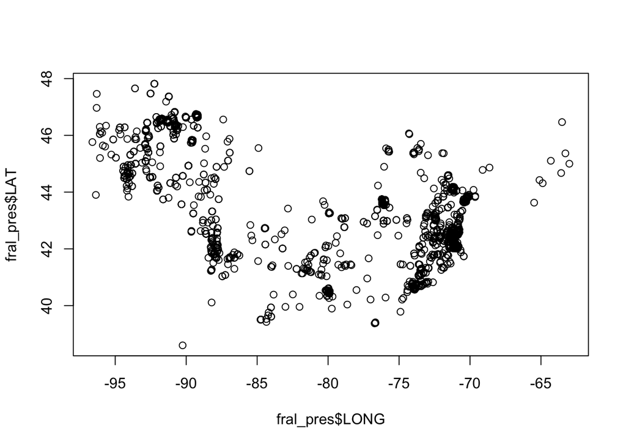

```r
plot(x = fral_pres$LONG, y = fral_pres$LAT)
```